# Primary Analysis of Psylect

Matthias Lüthi

2025-07-23

# 1 Setup

Load libraries, cleaned data & custom utility functions, define script-specific functions, create additional data frames for analysis

# 2 Figures

[figure not shown]

*Note.* Density/heat map showing participant distribution density over the greater area of São Paulo, Brazil. The red dot represents the study center (Instituto de Psiquiatria - HC/FMUSP, Rua Dr. Ovídio Pires de Campos, 785 CEP 05403-903, São Paulo - SP, Brazil).

The following figures show the development of all primary and secondary outcomes measures during the course of the study, separated by group. Error bars represent standard errors of the mean (SEM).

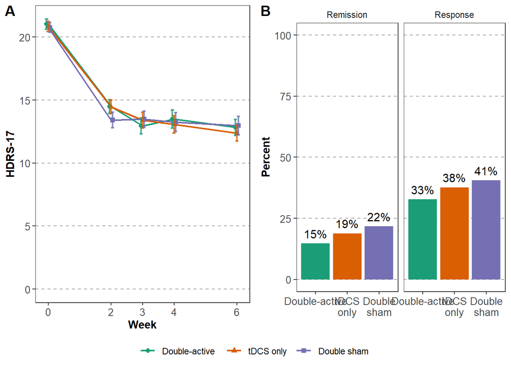

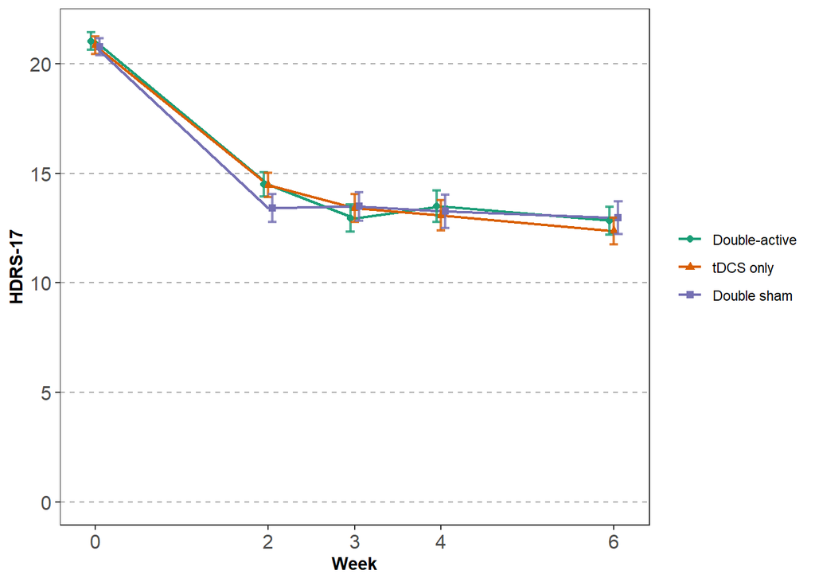

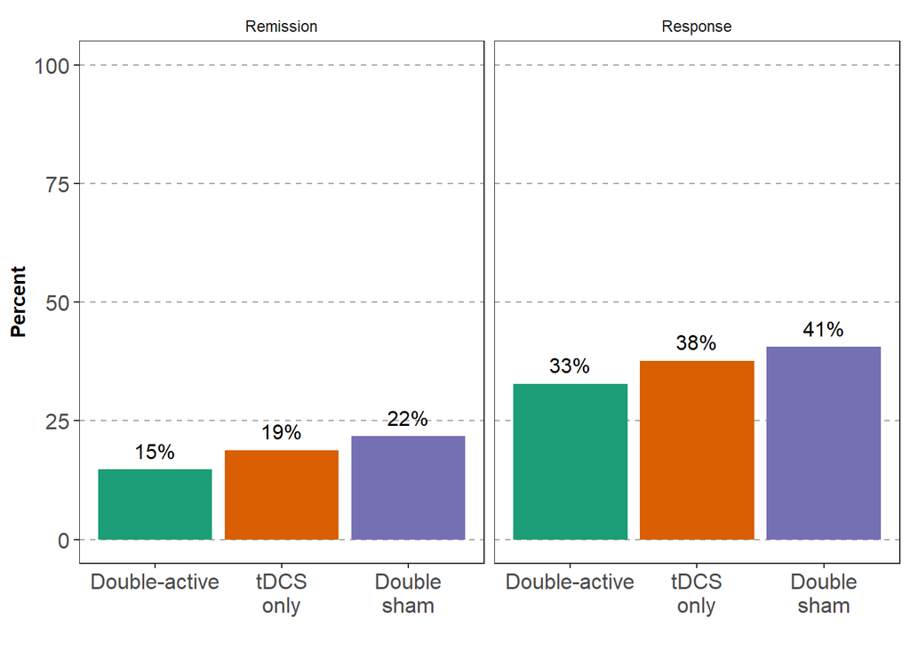

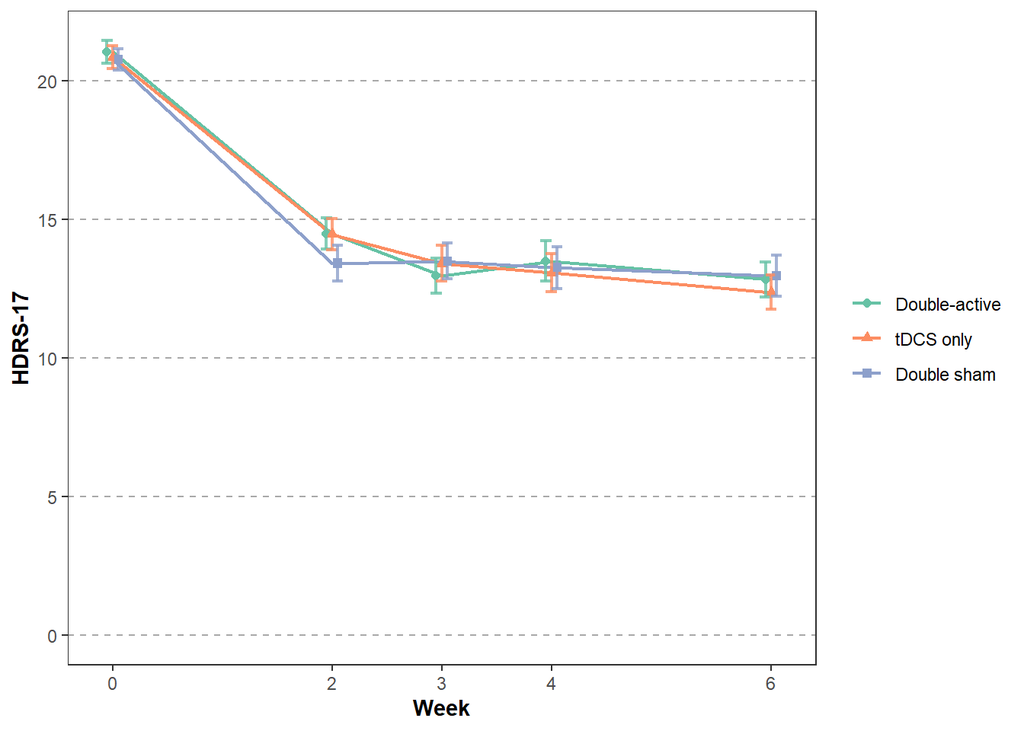

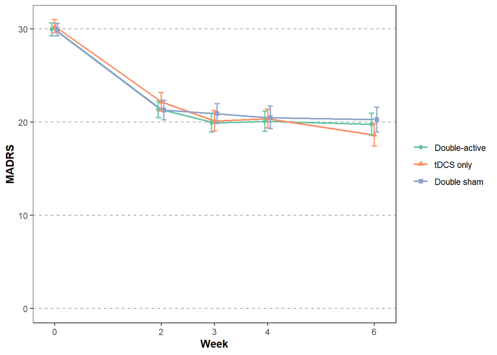

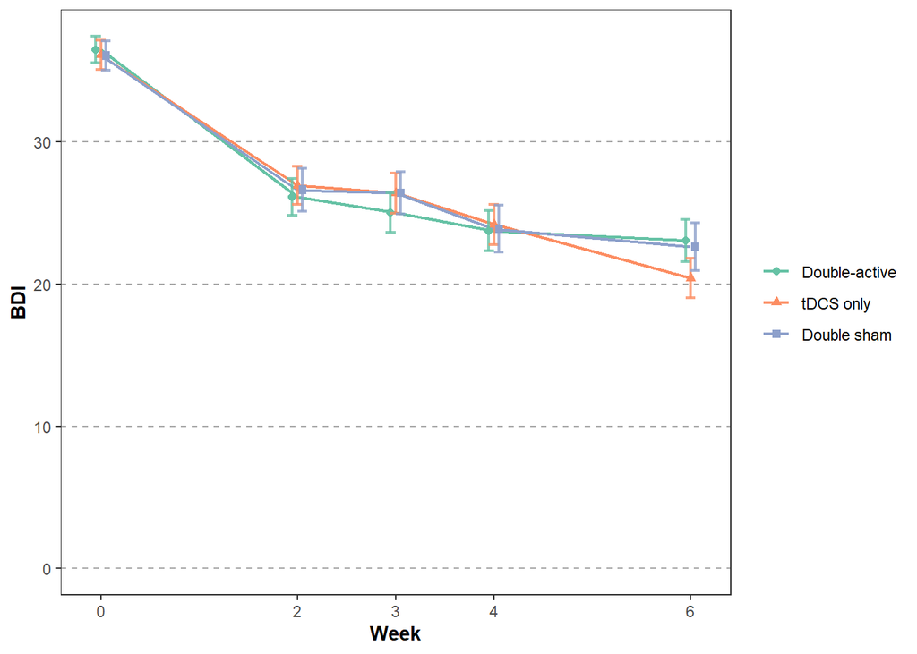

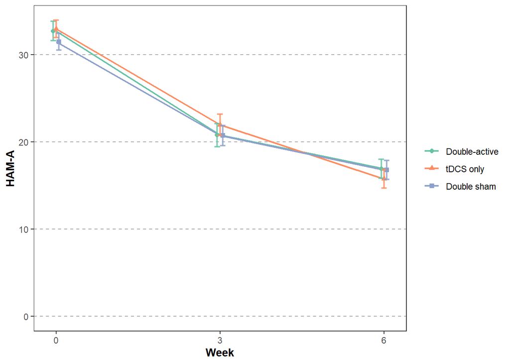

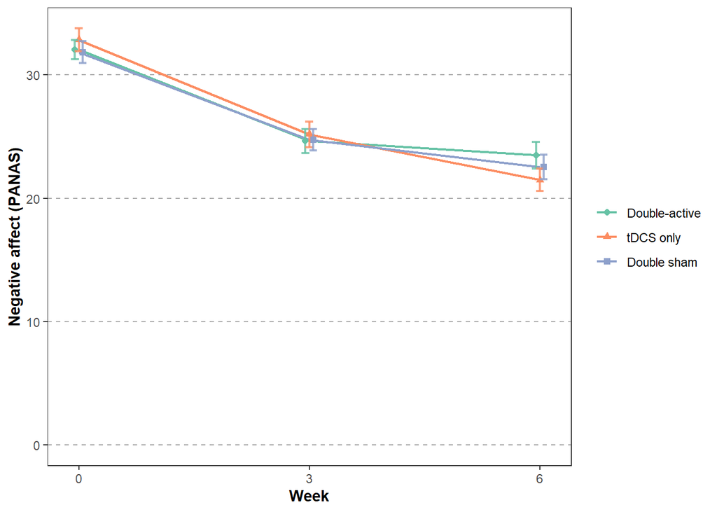

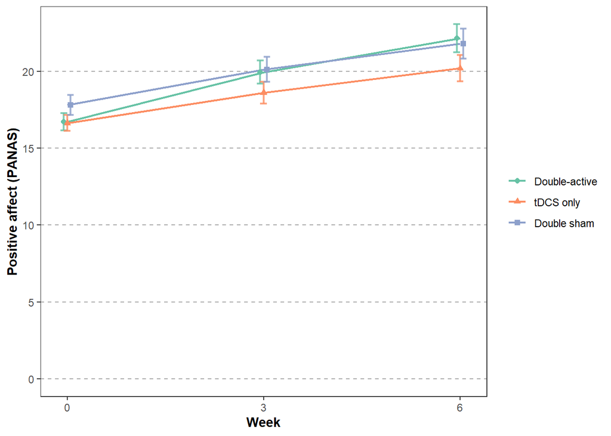

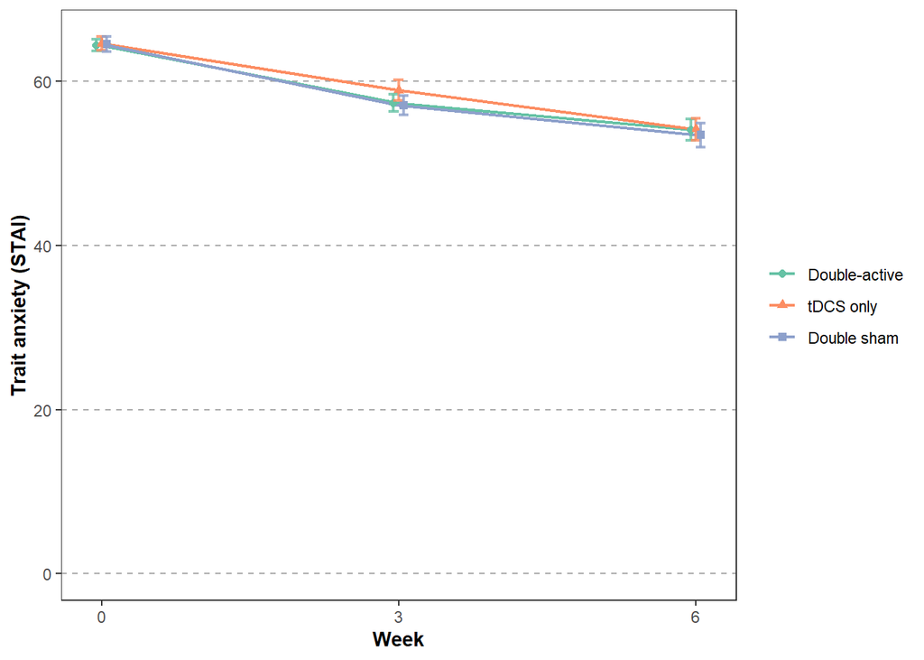

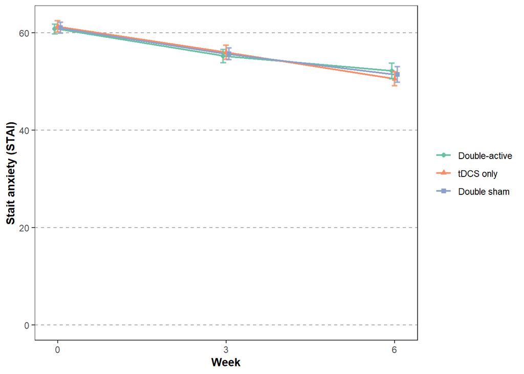

# 3 Tables

## 3.1 Clinical & demographic information

“Table 1”

| Characteristic | Double-active N = 64 | tDCS only N = 73 | Double sham N = 73 | P |
| --- | --- | --- | --- | --- |
| Demographics |  |  |  |  |
| Gender (% Female) | 54 (84) | 68 (93) | 58 (79) | 0.05 |
| Age, y | 38.7 ± 10.1 | 38.8 ± 9.1 | 39.2 ± 8.8 | 0.93 |
| White - no. (%) | 48 (75) | 54 (74) | 50 (68) | 0.65 |
| Completed grad. school - no. (%) | 40 (62) | 57 (78) | 51 (70) | 0.14 |
| ≤ 5 minimum wages, BRL$ - no. (%) | 33 (52) | 43 (59) | 43 (59) | 0.61 |
| Currently employed (% employment) | 36 (56) | 47 (64) | 58 (79) | 0.013 |
| Clinical characteristics |  |  |  |  |
| Onset age of MDD, years - mean (SD) | 24.5 ± 10.6 | 24.2 ± 8.6(N=72) | 25.6 ± 8.3(N=72) | 0.66 |
| No. previous depressive episodes - median (IQR) | 4 (2-5) | 3 (2-5)(N=71) | 3 (2-5)(N=71) | 0.56 |
| Duration of current episode, mo - mean (SD | 24 ± 39.9 | 34.5 ± 58.6(N=72) | 25 ± 22.9(N=72) | 0.28 |
| No. failed AD trials in life - median (IQR) | 1 (0-2) | 1 (0-2) | 1 (0-2) | 0.71 |
| min. 1 failed AD trial during current episode - no. (%) | 16 (25) | 21 (29) | 21 (29) | 0.85 |
| min. 2 failed AD trials during current episode - no. (%) | 6 (9) | 3 (4) | 3 (4) | 0.37 |
| Type of depression |  |  |  |  |
| Recurrent - no. (%) | 51 (80) | 62 (85) | 66 (90) | 0.21 |
| Chronic (>2y episode) - no. (%) | 19 (30) | 30 (41) | 32 (44) | 0.2 |
| Melancholic - no. (%) | 22 (34) | 26 (36) | 25 (34) | 0.98 |
| Comorbid anxiety disorders - no. (%) | 43 (67) | 56 (77) | 53 (73) | 0.46 |
| Family history of mental disorder - no. (%) | 54 (84) | 63 (86) | 66 (90) | 0.55 |
| Treatment in current depressive episode |  |  |  |  |
| SSRIs - no. (%) | 22 (34) | 23 (32) | 26 (36) | 0.87 |
| SNRIs - no. (%) | 16 (25) | 20 (27) | 19 (26) | 0.95 |
| Bupropion - no. (%) | 6 (9) | 11 (15) | 10 (14) | 0.59 |
| Other antidepressants - no. (%) | 13 (20) | 10 (14) | 12 (16) | 0.58 |
| No antidepressants - no. (%) | 23 (36) | 27 (37) | 22 (30) | 0.65 |
| Benzodiazepines - no. (%) | 17 (27) | 12 (16) | 14 (19) | 0.32 |
| Currently in psychotherapy - no. (%) | 19 (30) | 31 (42) | 37 (51) | 0.04 |
| Depression scales |  |  |  |  |
| HDRS-17 | 21 ± 3.3 | 20.8 ± 3.5 | 20.8 ± 3.3 | 0.89 |
| MADRS | 29.9 ± 5.7 | 30.3 ± 6.1 | 29.9 ± 5.7 | 0.92 |
| BDI-II | 36.5 ± 7.4 | 36.1 ± 8.7 | 36.1 ± 8.8(N=72) | 0.95 |

## 3.2 Table of outcomes

Summary table

| Scale | Week | Double-active Mean | Double-active SD | Double-active N | Double sham Mean | Double sham SD | Double sham N | tDCS only Mean | tDCS only SD | tDCS only N |
| --- | --- | --- | --- | --- | --- | --- | --- | --- | --- | --- |
| madrs | 0 | 29.94 | 5.68 | 64 | 29.92 | 5.68 | 73 | 30.26 | 6.14 | 73 |
| madrs | 2 | 21.36 | 6.93 | 64 | 21.29 | 9.03 | 72 | 22.18 | 8.46 | 72 |
| madrs | 3 | 19.94 | 7.97 | 64 | 20.92 | 8.99 | 72 | 20.13 | 9.11 | 69 |
| madrs | 4 | 20.10 | 8.61 | 63 | 20.49 | 10.28 | 72 | 20.38 | 8.25 | 69 |
| madrs | 6 | 19.75 | 9.23 | 61 | 20.26 | 10.97 | 69 | 18.62 | 9.98 | 69 |
| hamd | 0 | 21.03 | 3.27 | 64 | 20.77 | 3.27 | 73 | 20.84 | 3.48 | 73 |
| hamd | 2 | 14.48 | 4.43 | 64 | 13.42 | 5.36 | 72 | 14.46 | 4.72 | 72 |
| hamd | 3 | 12.95 | 5.03 | 64 | 13.49 | 5.47 | 72 | 13.41 | 5.34 | 69 |
| hamd | 4 | 13.49 | 5.77 | 63 | 13.26 | 6.40 | 72 | 13.07 | 5.70 | 69 |
| hamd | 6 | 12.82 | 4.96 | 61 | 12.97 | 6.17 | 69 | 12.36 | 5.13 | 69 |
| bdi | 0 | 36.48 | 7.42 | 64 | 36.06 | 8.75 | 72 | 36.10 | 8.74 | 73 |
| bdi | 2 | 26.13 | 10.16 | 63 | 26.62 | 12.82 | 71 | 26.93 | 11.52 | 72 |
| bdi | 3 | 25.02 | 11.17 | 63 | 26.42 | 12.63 | 72 | 26.39 | 11.67 | 69 |
| bdi | 4 | 23.74 | 11.11 | 62 | 23.89 | 13.95 | 70 | 24.19 | 11.56 | 67 |
| bdi | 6 | 23.03 | 11.61 | 61 | 22.62 | 14.00 | 69 | 20.43 | 11.35 | 68 |
| stai_t | 0 | 64.38 | 5.49 | 64 | 64.49 | 7.78 | 73 | 64.58 | 7.19 | 73 |
| stai_t | 3 | 57.35 | 8.02 | 63 | 57.06 | 9.68 | 72 | 58.88 | 10.37 | 69 |
| stai_t | 6 | 54.07 | 10.10 | 61 | 53.42 | 11.96 | 69 | 54.14 | 10.95 | 69 |
| stai_s | 0 | 60.75 | 8.19 | 64 | 61.01 | 9.59 | 73 | 61.27 | 9.98 | 73 |
| stai_s | 3 | 55.19 | 10.84 | 63 | 55.67 | 10.20 | 72 | 55.99 | 12.06 | 68 |
| stai_s | 6 | 52.15 | 12.26 | 61 | 51.42 | 13.46 | 69 | 50.54 | 11.97 | 69 |
| panas_positive | 0 | 16.72 | 4.52 | 64 | 17.79 | 5.58 | 73 | 16.62 | 4.36 | 72 |
| panas_positive | 3 | 19.94 | 6.02 | 63 | 20.11 | 6.84 | 72 | 18.60 | 5.84 | 68 |
| panas_positive | 6 | 22.13 | 7.17 | 61 | 21.80 | 8.07 | 69 | 20.19 | 6.96 | 68 |
| panas_negative | 0 | 32.06 | 6.24 | 64 | 31.84 | 7.57 | 73 | 32.85 | 7.83 | 72 |
| panas_negative | 3 | 24.65 | 7.68 | 63 | 24.75 | 7.37 | 72 | 25.19 | 8.60 | 68 |
| panas_negative | 6 | 23.49 | 8.56 | 61 | 22.54 | 8.40 | 69 | 21.50 | 7.46 | 68 |
| hama | 0 | 32.70 | 8.90 | 64 | 31.48 | 8.06 | 73 | 32.95 | 8.50 | 73 |
| hama | 3 | 20.78 | 10.60 | 64 | 20.74 | 9.76 | 72 | 21.96 | 9.93 | 68 |
| hama | 6 | 16.92 | 8.51 | 61 | 16.77 | 9.01 | 69 | 15.75 | 8.79 | 69 |

Complete outcome table for supplementary material

| Groups | Scale | w0 | w2 | w3 | w4 | w6 |
| --- | --- | --- | --- | --- | --- | --- |
| Double-active | madrs | 29.94 ± 5.68 | 21.36 ± 6.93 | 19.94 ± 7.97 | 20.1 ± 8.61 | 19.75 ± 9.23 |
| tDCS only | madrs | 30.26 ± 6.14 | 22.18 ± 8.46 | 20.13 ± 9.11 | 20.38 ± 8.25 | 18.62 ± 9.98 |
| Double sham | madrs | 29.92 ± 5.68 | 21.29 ± 9.03 | 20.92 ± 8.99 | 20.49 ± 10.28 | 20.26 ± 10.97 |
| Double-active | hamd | 21.03 ± 3.27 | 14.48 ± 4.43 | 12.95 ± 5.03 | 13.49 ± 5.77 | 12.82 ± 4.96 |
| tDCS only | hamd | 20.84 ± 3.48 | 14.46 ± 4.72 | 13.41 ± 5.34 | 13.07 ± 5.7 | 12.36 ± 5.13 |
| Double sham | hamd | 20.77 ± 3.27 | 13.42 ± 5.36 | 13.49 ± 5.47 | 13.26 ± 6.4 | 12.97 ± 6.17 |
| Double-active | bdi | 36.48 ± 7.42 | 26.13 ± 10.16 | 25.02 ± 11.17 | 23.74 ± 11.11 | 23.03 ± 11.61 |
| tDCS only | bdi | 36.1 ± 8.74 | 26.93 ± 11.52 | 26.39 ± 11.67 | 24.19 ± 11.56 | 20.43 ± 11.35 |
| Double sham | bdi | 36.06 ± 8.75 | 26.62 ± 12.82 | 26.42 ± 12.63 | 23.89 ± 13.95 | 22.62 ± 14 |
| Double-active | stai_t | 64.38 ± 5.49 |  | 57.35 ± 8.02 |  | 54.07 ± 10.1 |
| tDCS only | stai_t | 64.58 ± 7.19 |  | 58.88 ± 10.37 |  | 54.14 ± 10.95 |
| Double sham | stai_t | 64.49 ± 7.78 |  | 57.06 ± 9.68 |  | 53.42 ± 11.96 |
| Double-active | stai_s | 60.75 ± 8.19 |  | 55.19 ± 10.84 |  | 52.15 ± 12.26 |
| tDCS only | stai_s | 61.27 ± 9.98 |  | 55.99 ± 12.06 |  | 50.54 ± 11.97 |
| Double sham | stai_s | 61.01 ± 9.59 |  | 55.67 ± 10.2 |  | 51.42 ± 13.46 |
| Double-active | panas_positive | 16.72 ± 4.52 |  | 19.94 ± 6.02 |  | 22.13 ± 7.17 |
| tDCS only | panas_positive | 16.62 ± 4.36 |  | 18.6 ± 5.84 |  | 20.19 ± 6.96 |
| Double sham | panas_positive | 17.79 ± 5.58 |  | 20.11 ± 6.84 |  | 21.8 ± 8.07 |
| Double-active | panas_negative | 32.06 ± 6.24 |  | 24.65 ± 7.68 |  | 23.49 ± 8.56 |
| tDCS only | panas_negative | 32.85 ± 7.83 |  | 25.19 ± 8.6 |  | 21.5 ± 7.46 |
| Double sham | panas_negative | 31.84 ± 7.57 |  | 24.75 ± 7.37 |  | 22.54 ± 8.4 |
| Double-active | hama | 32.7 ± 8.9 |  | 20.78 ± 10.6 |  | 16.92 ± 8.51 |
| tDCS only | hama | 32.95 ± 8.5 |  | 21.96 ± 9.93 |  | 15.75 ± 8.79 |
| Double sham | hama | 31.48 ± 8.06 |  | 20.74 ± 9.76 |  | 16.77 ± 9.01 |
| Double-active | cgi_2 | 0 ± 0 |  |  |  | 2.7 ± 1.13 |
| tDCS only | cgi_2 | 0 ± 0 |  |  |  | 2.65 ± 1.08 |
| Double sham | cgi_2 | 0 ± 0 |  |  |  | 2.75 ± 1.42 |
| Double-active | cgi_1 | 4.5 ± 0.59 |  |  |  | 3.38 ± 1.1 |
| tDCS only | cgi_1 | 4.32 ± 0.7 |  |  |  | 3.13 ± 1.17 |
| Double sham | cgi_1 | 4.51 ± 0.71 |  |  |  | 3.3 ± 1.36 |

# 4 Analysis of treatment effects

For each outcome variable, a linear mixed model was set up with the outcome as dependent variable, time and group as fixed effects, and participant as random effect. The main interest are interactions of group and time, and a significant result would indicate that changes of the outcome depended on group (treatment). However, because there are three groups, a significant result would not tell us which groups differ. Thus, in accordance with the registered and published study protocol, there are 3 co-primary hypotheses: 3 contrasts were set up to test and compare the possible pairs of the 3 groups.

## 4.1 Primary outcome

The primary outcome was the Hamilton Depression Rating scale, 17-item version (HDRS-17/HAMD).

| Group | Baseline | Week 2 | Week 3 | Week 4 | Week 6 | Change until week 6 |
| --- | --- | --- | --- | --- | --- | --- |
| Double active | 21.03 ± 3.27 | 14.48 ± 4.43 | 12.95 ± 5.03 | 13.49 ± 5.77 | 12.82 ± 4.96 | -7.79 [-9.32, -6.26] |
| tDCS only | 20.84 ± 3.48 | 14.46 ± 4.72 | 13.41 ± 5.34 | 13.07 ± 5.7 | 12.36 ± 5.13 | -7.98 [-9.43, -6.53] |
| Double sham | 20.77 ± 3.27 | 13.42 ± 5.36 | 13.49 ± 5.47 | 13.26 ± 6.4 | 12.97 ± 6.17 | -7.01 [-8.45, -5.58] |

*Note:* Means and standard deviations of HDRS scores per group at each timepoint, and the score changes until week 6, which is the average change as estimated by a linear mixed model, together with 95% confidence intervals.

| Contrast | Beta | t | DF | P | Cohen's d |
| --- | --- | --- | --- | --- | --- |
| Double active vs. tDCS only | 0.03 [-0.39, 0.45] | 0.18 | 201 | 0.855 | 0.05 [-0.48, 0.58] |
| Double active vs. double sham | -0.13 [-0.55, 0.29] | -0.73 | 202 | 0.468 | -0.2 [-0.73, 0.34] |
| tDCS only vs. double sham | -0.16 [-0.57, 0.25] | -0.94 | 201 | 0.350 | -0.25 [-0.76, 0.27] |

*Note:* Contrasts (main results) based on comparisons of the average changes (slopes) between groups, together with common test statistics and effect size Cohen’s D with 95% confidence intervals.

It is also possible to test the overall effect of group with a likelihood-ratio-test. This does not differentiate betweeen groups, and thus is less informative, but since nothing is significant, it can be used to summarize the results more easily, such as: A likelihood ratio test indicated that HDRS-17 changes over time did not significantly differ between groups, χ2 = 0.98, DF = 2, P = 0.613.

## 4.2 Response & Remission

| Condition | Type | Week 2 | Week 3 | Week 4 | Week 6 |
| --- | --- | --- | --- | --- | --- |
| Double-active | Response - no. (%) | 12 (19) | 21 (33) | 24 (38) | 20 (33) |
| Double-active | Remission - no. (%) | 5 (8) | 10 (16) | 8 (13) | 9 (15) |
| tDCS only | Response - no. (%) | 13 (18) | 21 (30) | 19 (28) | 26 (38) |
| tDCS only | Remission - no. (%) | 6 (8) | 9 (13) | 10 (14) | 13 (19) |
| Double sham | Response - no. (%) | 20 (28) | 23 (32) | 24 (33) | 28 (41) |
| Double sham | Remission - no. (%) | 12 (17) | 9 (12) | 15 (21) | 15 (22) |

```
## Likelihood ratio test
##
## Model 1: hamd_response ~ 1
## Model 2: hamd_response ~ Groups
##   #Df  LogLik Df Chisq Pr(>Chisq)
## 1   1 -131.33
## 2   3 -130.90  2 0.858     0.6511
```

## 4.3 Secondary outcomes

| Characteristic | Change until week 6 Double active | Change until week 6 mtDCS only | Change until week 6 Double sham | Double active vs. mtDCS only P | Double active vs. mtDCS only Cohen's d | Double active vs. double sham P | Double active vs. double sham Cohen's d | mtDCS only vs. double sham P | mtDCS only vs. double sham Cohen's d |
| --- | --- | --- | --- | --- | --- | --- | --- | --- | --- |
| HDRS-17 | -7.79 [-9.32, -6.26] | -7.98 [-9.43, -6.53] | -7.01 [-8.45, -5.58] | 0.855 | 0.05 [-0.48, 0.58] | 0.468 | -0.2 [-0.73, 0.34] | 0.35 | -0.25 [-0.76, 0.27] |
| MADRS | -9.82 [-12.27, -7.36] | -10.71 [-13.04, -8.38] | -8.79 [-11.09, -6.48] | 0.604 | 0.15 [-0.43, 0.74] | 0.547 | -0.18 [-0.76, 0.41] | 0.249 | -0.33 [-0.9, 0.24] |
| BDI | -13.38 [-16.29, -10.46] | -14.5 [-17.28, -11.72] | -12.73 [-15.48, -9.99] | 0.584 | 0.18 [-0.47, 0.83] | 0.752 | -0.1 [-0.75, 0.54] | 0.374 | -0.29 [-0.92, 0.35] |
| CGI-S | -1.12 [-1.41, -0.83] | -1.18 [-1.45, -0.9] | -1.2 [-1.48, -0.93] | 0.781 | 0.07 [-0.42, 0.55] | 0.689 | 0.1 [-0.39, 0.58] | 0.9 | 0.03 [-0.44, 0.5] |
| HAM-A | -15.85 [-18.13, -13.57] | -17.11 [-19.26, -14.96] | -14.78 [-16.92, -12.64] | 0.43 | 0.2 [-0.3, 0.71] | 0.502 | -0.17 [-0.68, 0.33] | 0.133 | -0.38 [-0.87, 0.12] |
| STAI-S | -8.6 [-11.84, -5.37] | -10.77 [-13.83, -7.7] | -9.2 [-12.25, -6.16] | 0.34 | 0.32 [-0.34, 0.97] | 0.791 | 0.09 [-0.56, 0.74] | 0.476 | -0.23 [-0.86, 0.4] |
| STAI-T | -10.46 [-13.04, -7.88] | -10.49 [-12.94, -8.04] | -10.67 [-13.1, -8.24] | 0.987 | 0.01 [-0.61, 0.62] | 0.906 | 0.04 [-0.58, 0.65] | 0.917 | 0.03 [-0.56, 0.63] |
| PANAS negative | -8.68 [-10.66, -6.7] | -11.28 [-13.16, -9.4] | -9.15 [-11.01, -7.29] | 0.062 | 0.51 [-0.03, 1.05] | 0.736 | 0.09 [-0.44, 0.62] | 0.114 | -0.42 [-0.94, 0.1] |
| PANAS positive | 5.37 [3.45, 7.29] | 3.62 [1.79, 5.45] | 3.93 [2.12, 5.73] | 0.194 | 0.46 [-0.23, 1.14] | 0.282 | 0.37 [-0.31, 1.06] | 0.813 | -0.08 [-0.75, 0.59] |

*Note.* Change in scores was calculated by obtaining the slope (average change per week) and multiplying it by 6 (the number of weeks). P-values are displayed without multiplicity correction. All models were fit with a random intercept and random slope, except CGI-S was fit with random intercept only because of convergence issues. HDRS-17 Hamilton Depression Rating Scale; BDI Beck Depression Inventory; MADRS Montgomery-Åsberg Depression Rating Scale; CGI Clinical Global Impression; HAM-A Hamilton Anxiety Rating Scale; PANAS Positive and Negative Affect Scale; STAI State-Trait Anxiety Inventory; mtDCS: mobile transcranial direct current stimulation.

If we follow the logic through with moving HDRS results to the main manuscript, we can remove HDRS from this table and present it as “secondary outcomes”.

## 4.4 Subgroup analyses

Subgroup analyses were conducted with liner mixed modeling. Fixed effects were group, time, and the subgroup variable, while subject was a random effect with random slope and intercept. The interaction of group, time and subgroup was evaluated using Type III analyses of variance with Satterthwaite estimation of degrees of freedom.

| Predictor | F | Numerator DF | Denominator DF | P |
| --- | --- | --- | --- | --- |
| Currently in psychotherapy (1) | 0.52 | 2 | 311 | 0.596 |
| HDRS-17 baseline score (2) | 0.46 | 2 | 256 | 0.631 |
| Duration (months) of current depression (2) | 0.53 | 2 | 310 | 0.586 |
| No. failed AD trials in current episode (2) | 2.97 | 2 | 319 | 0.052 |

*Note:* (1) Categorical predictor (yes/no), (2) Numeric predictor. DF degrees of freedom.

# 5 Blinding integrity

Chi-square tests to see if participants remained blinded with regard to their experimental condition.

|  | Double sham | Double-active | tDCS only | Chi-square |  |
| --- | --- | --- | --- | --- | --- |
| Brain stimulation |  |  |  |  |  |
| Guess active tDCS | 40 (58%) | 46 (75%) | 56 (81%) | χ2 = 9.78, P = 0.008 |  |
| Guess sham tDCS | 29 (42%) | 15 (25%) | 13 (19%) |  |  |
| Digital intervention |  |  |  |  |  |
| Guess active DI | 31 (45%) | 46 (75%) | 37 (54%) |  | χ2 = 12.87, P = 0.002 |
| Guess sham DI | 38 (55%) | 15 (25%) | 32 (46%) |  |  |

# 6 Adverse Events

| Event | Double-active (N = 61) | tDCS only (N = 69) | Double sham (N = 69) | P Value Double-active vs. Double sham | P Value tDCS only vs. Double sham | P Value Double-active vs. tDCS only |
| --- | --- | --- | --- | --- | --- | --- |
| Severity of reported adverse event at week 6 — no. (%) |  |  |  |  |  |  |
| No adverse event reported | 8 (13) | 15 (22) | 15 (22) | .252 | > .999 | .252 |
| ≥ 1 mild adverse event | 46 (75) | 50 (72) | 47 (68) | .437 | .71 | .842 |
| ≥ 1 moderate adverse event | 19 (31) | 24 (35) | 14 (20) | .165 | .086 | .711 |
| ≥ 1 severe adverse event | 3 (5) | 2 (3) | 2 (3) | .665 | > .999 | .665 |
| Median no. of reported adverse events at week 6 (interquartile range) |  |  |  |  |  |  |
| Mild adverse events | 1 (1-3) | 2 (0-3) | 1 (0-2) | .266 | .149 | .79 |
| Moderate adverse events | 0 (0-1) | 0 (0-1) | 0 (0-0) | .205 | .23 | .827 |
| Severe adverse events | 0 (0-0) | 0 (0-0) | 0 (0-0) | .321 | > .999 | .321 |

*Note:* Tthe last week (here week 6) is evaluated and an adverse event had to be at least remotely associated with tDCS to be included. For tests of significance, the chi-square test was used to compare presence of adverse events, and negative binomial regression for the counts of adverse events.

## 6.1 Each adverse event separately

Extensive material for supplement

| Event | Double-active | tDCS only | Double sham | Double-active vs. tDCS only | Double-active vs. Double sham | tDCS only vs. Double sham | active tDCS vs. sham tDCS |
| --- | --- | --- | --- | --- | --- | --- | --- |
| Tingling |  |  |  |  |  |  |  |
| Mild | 21 (34) | 20 (29) | 28 (41) | 0.57 | 0.59 | 0.21 | 0.26 |
| Moderate | 2 (3) | 4 (6) | 5 (7) | 0.68 | 0.45 | >0.99 | 0.52 |
| Severe | 0 (0) | 0 (0) | 0 (0) | - | - | - | - |
| Total | 23 (38) | 24 (35) | 33 (48) | 0.86 | 0.29 | 0.17 | 0.15 |
| Local redness |  |  |  |  |  |  |  |
| Mild | 29 (48) | 26 (38) | 11 (16) | 0.29 | <0.001 | 0.007 | <0.001 |
| Moderate | 4 (7) | 7 (10) | 0 (0) | 0.54 | 0.05 | 0.01 | 0.009 |
| Severe | 1 (2) | 0 (0) | 0 (0) | 0.47 | 0.47 | - | >0.99 |
| Total | 34 (56) | 33 (48) | 11 (16) | 0.38 | <0.001 | <0.001 | <0.001 |
| Heat/Burning |  |  |  |  |  |  |  |
| Mild | 14 (23) | 21 (30) | 11 (16) | 0.43 | 0.38 | 0.07 | 0.12 |
| Moderate | 8 (13) | 3 (4) | 2 (3) | 0.11 | 0.04 | >0.99 | 0.23 |
| Severe | 1 (2) | 0 (0) | 0 (0) | 0.47 | 0.47 | - | >0.99 |
| Total | 23 (38) | 24 (35) | 13 (19) | 0.86 | 0.02 | 0.05 | 0.02 |
| Somnolence |  |  |  |  |  |  |  |
| Mild | 11 (18) | 19 (28) | 12 (17) | 0.22 | >0.99 | 0.22 | 0.45 |
| Moderate | 6 (10) | 5 (7) | 4 (6) | 0.76 | 0.51 | >0.99 | 0.58 |
| Severe | 2 (3) | 1 (1) | 0 (0) | 0.6 | 0.22 | >0.99 | 0.55 |
| Total | 19 (31) | 25 (36) | 16 (23) | 0.58 | 0.33 | 0.14 | 0.16 |
| Itching |  |  |  |  |  |  |  |
| Mild | 11 (18) | 13 (19) | 18 (26) | >0.99 | 0.3 | 0.42 | 0.28 |
| Moderate | 3 (5) | 4 (6) | 3 (4) | >0.99 | >0.99 | >0.99 | >0.99 |
| Severe | 0 (0) | 0 (0) | 0 (0) | - | - | - | - |
| Total | 14 (23) | 17 (25) | 21 (30) | 0.84 | 0.43 | 0.57 | 0.4 |
| Headache |  |  |  |  |  |  |  |
| Mild | 4 (7) | 10 (14) | 5 (7) | 0.17 | >0.99 | 0.27 | 0.61 |
| Moderate | 5 (8) | 3 (4) | 2 (3) | 0.47 | 0.25 | >0.99 | 0.5 |
| Severe | 0 (0) | 0 (0) | 0 (0) | - | - | - | - |
| Total | 9 (15) | 13 (19) | 7 (10) | 0.64 | 0.44 | 0.23 | 0.28 |
| Concentration diffculties |  |  |  |  |  |  |  |
| Mild | 2 (3) | 6 (9) | 3 (4) | 0.28 | >0.99 | 0.49 | 0.75 |
| Moderate | 1 (2) | 3 (4) | 2 (3) | 0.62 | >0.99 | >0.99 | >0.99 |
| Severe | 0 (0) | 0 (0) | 0 (0) | - | - | - | - |
| Total | 3 (5) | 9 (13) | 5 (7) | 0.14 | 0.72 | 0.4 | 0.79 |
| Fatigue |  |  |  |  |  |  |  |
| Mild | 3 (5) | 1 (1) | 2 (3) | 0.34 | 0.66 | >0.99 | >0.99 |
| Moderate | 0 (0) | 2 (3) | 5 (7) | 0.5 | 0.06 | 0.44 | 0.05 |
| Severe | 1 (2) | 1 (1) | 1 (1) | >0.99 | >0.99 | >0.99 | >0.99 |
| Total | 4 (7) | 4 (6) | 8 (12) | >0.99 | 0.38 | 0.37 | 0.28 |
| Buzzing |  |  |  |  |  |  |  |
| Mild | 3 (5) | 5 (7) | 3 (4) | 0.72 | >0.99 | 0.72 | 0.75 |
| Moderate | 2 (3) | 2 (3) | 0 (0) | >0.99 | 0.22 | 0.5 | 0.3 |
| Severe | 0 (0) | 0 (0) | 0 (0) | - | - | - | - |
| Total | 5 (8) | 7 (10) | 3 (4) | 0.77 | 0.47 | 0.32 | 0.27 |
| Pain at the left side |  |  |  |  |  |  |  |
| Mild | 5 (8) | 2 (3) | 1 (1) | 0.25 | 0.1 | >0.99 | 0.27 |
| Moderate | 0 (0) | 2 (3) | 0 (0) | 0.5 | - | 0.5 | 0.54 |
| Severe | 0 (0) | 0 (0) | 0 (0) | - | - | - | - |
| Total | 5 (8) | 4 (6) | 1 (1) | 0.73 | 0.1 | 0.37 | 0.17 |
| Pain on the right side |  |  |  |  |  |  |  |
| Mild | 5 (8) | 4 (6) | 1 (1) | 0.73 | 0.1 | 0.37 | 0.17 |
| Moderate | 0 (0) | 0 (0) | 0 (0) | - | - | - | - |
| Severe | 0 (0) | 0 (0) | 0 (0) | - | - | - | - |
| Total | 5 (8) | 4 (6) | 1 (1) | 0.73 | 0.1 | 0.37 | 0.17 |
| Dizziness |  |  |  |  |  |  |  |
| Mild | 1 (2) | 1 (1) | 2 (3) | >0.99 | >0.99 | >0.99 | 0.61 |
| Moderate | 2 (3) | 1 (1) | 0 (0) | 0.6 | 0.22 | >0.99 | 0.55 |
| Severe | 0 (0) | 0 (0) | 1 (1) | - | >0.99 | >0.99 | 0.35 |
| Total | 3 (5) | 2 (3) | 3 (4) | 0.66 | >0.99 | >0.99 | >0.99 |
| Mood worsening |  |  |  |  |  |  |  |
| Mild | 0 (0) | 1 (1) | 1 (1) | >0.99 | >0.99 | >0.99 | >0.99 |
| Moderate | 2 (3) | 1 (1) | 2 (3) | 0.6 | >0.99 | >0.99 | >0.99 |
| Severe | 0 (0) | 0 (0) | 0 (0) | - | - | - | - |
| Total | 2 (3) | 2 (3) | 3 (4) | >0.99 | >0.99 | >0.99 | 0.7 |
| Nausea |  |  |  |  |  |  |  |
| Mild | 0 (0) | 1 (1) | 3 (4) | >0.99 | 0.25 | 0.62 | 0.12 |
| Moderate | 0 (0) | 1 (1) | 0 (0) | >0.99 | - | >0.99 | >0.99 |
| Severe | 0 (0) | 0 (0) | 0 (0) | - | - | - | - |
| Total | 0 (0) | 2 (3) | 3 (4) | 0.5 | 0.25 | >0.99 | 0.34 |
| Neck ache |  |  |  |  |  |  |  |
| Mild | 1 (2) | 0 (0) | 1 (1) | 0.47 | >0.99 | >0.99 | >0.99 |
| Moderate | 1 (2) | 0 (0) | 0 (0) | 0.47 | 0.47 | - | >0.99 |
| Severe | 0 (0) | 0 (0) | 0 (0) | - | - | - | - |
| Total | 2 (3) | 0 (0) | 1 (1) | 0.22 | 0.6 | >0.99 | >0.99 |